# Trabajo practico 1

Ejercicio 5

05 mayo, 2021

## Librerias y utilidades

```r
library(ape)
library(ggrepel)
library(kableExtra)
library(tidyverse)
source(here::here("src", "utils.R"))
```

## Datos

```r
datos <- read_csv2(here::here("data", "raw", "RAPDS.csv"))
glimpse(datos)
```

```
## Rows: 41
## Columns: 34
## $ Var <chr> "A1", "A2", "A3", "A4", "A5", "A6", "A7", "A8", "F1", "F2", "F3", …
## $ B01 <dbl> 1.0, 1.0, 1.0, 1.0, 0.0, 0.0, 0.0, 1.0, 0.0, 1.0, 1.0, 1.0, 0.5, 0…
## $ B02 <dbl> 1, 1, 0, 0, 0, 0, 0, 0, 1, 1, 1, 1, 1, 1, 1, 1, 1, 1, 1, 0, 0, 0, …
## $ B03 <dbl> 1.00, 0.00, 1.00, 1.00, 1.00, 1.00, 1.00, 1.00, 0.00, 0.25, 0.00, …
## $ B04 <dbl> 0, 1, 0, 0, 0, 0, 0, 0, 0, 1, 0, 0, 1, 0, 0, 0, 0, 0, 0, 1, 0, 0, …
## $ B05 <dbl> 0.0, 0.0, 0.0, 0.0, 0.0, 0.0, 0.0, 0.0, 0.0, 0.0, 0.0, 0.0, 0.5, 0…
## $ B06 <dbl> 0.00, 0.00, 0.00, 0.00, 0.00, 0.00, 0.00, 0.00, 1.00, 0.25, 1.00, …
## $ B07 <dbl> 1.00, 1.00, 0.00, 0.00, 0.00, 0.00, 0.00, 0.00, 1.00, 0.75, 1.00, …
## $ B08 <dbl> 0.00, 0.00, 0.00, 0.00, 0.00, 0.00, 0.00, 0.00, 1.00, 0.75, 1.00, …
## $ B09 <dbl> 1, 0, 0, 0, 0, 0, 0, 0, 0, 0, 0, 0, 0, 0, 0, 0, 0, 0, 0, 0, 0, 0, …
## $ B10 <dbl> 0, 0, 0, 0, 0, 0, 0, 0, 0, 0, 0, 0, 0, 0, 0, 0, 0, 0, 0, 1, 1, 1, …
## $ B11 <dbl> 0, 0, 0, 0, 0, 0, 0, 0, 0, 0, 0, 0, 1, 0, 0, 0, 0, 0, 0, 0, 0, 0, …
## $ B12 <dbl> 1, 0, 0, 0, 0, 0, 0, 0, 0, 0, 0, 0, 0, 1, 0, 0, 0, 0, 0, 0, 0, 0, …
```

[output cut: 21 more lines]

**A.** Halle la distancia genética de Prevosti entre variedades

```r
# Dist computa distancia entre filas, y las filas de datos son las variedades.
# 33 es la cantidad de variables
datos_df <- data.frame(datos[-1])
rownames(datos_df) <- datos$Var
matriz_distancia <- dist(datos_df, method = "manhattan", diag = TRUE) / 33
```

```r
matriz_distancia %>%
    as.matrix() %>%
    round(2) %>%
    kable() %>%
    kable_styling(font_size = 12) %>%
    kable_classic_2() %>%
    scroll_box(height = "300px", width = "100%")
```

|  | A1 | A2 | A3 | A4 | A5 | A6 | A7 | A8 | F1 | F2 | F3 | F4 | F5 | F6 | F7 | F8 | F9 | F10 | F11 | H1 | H2 | H3 | H4 | H5 | H6 | H7 | H8 | H9 | H10 | … |
| --- | --- | --- | --- | --- | --- | --- | --- | --- | --- | --- | --- | --- | --- | --- | --- | --- | --- | --- | --- | --- | --- | --- | --- | --- | --- | --- | --- | --- | --- | --- |
| A1 | 0.00 | 0.27 | 0.30 | 0.33 | 0.30 | 0.39 | 0.39 | 0.33 | 0.55 | 0.47 | 0.52 | 0.52 | 0.60 | 0.42 | 0.52 | 0.52 | 0.40 | 0.45 | 0.42 | 0.36 | 0.33 | 0.30 | 0.30 | 0.33 | 0.33 | 0.24 | 0.24 | 0.24 | 0.33 | … |
| A2 | 0.27 | 0.00 | 0.33 | 0.30 | 0.33 | 0.30 | 0.30 | 0.24 | 0.45 | 0.33 | 0.42 | 0.42 | 0.40 | 0.33 | 0.42 | 0.42 | 0.37 | 0.36 | 0.39 | 0.21 | 0.36 | 0.33 | 0.33 | 0.30 | 0.30 | 0.39 | 0.39 | 0.27 | 0.30 | … |
| A3 | 0.30 | 0.33 | 0.00 | 0.03 | 0.18 | 0.15 | 0.15 | 0.09 | 0.42 | 0.41 | 0.39 | 0.39 | 0.59 | 0.36 | 0.33 | 0.45 | 0.34 | 0.33 | 0.30 | 0.24 | 0.21 | 0.18 | 0.18 | 0.15 | 0.15 | 0.18 | 0.18 | 0.18 | 0.21 | … |
| A4 | 0.33 | 0.30 | 0.03 | 0.00 | 0.15 | 0.12 | 0.12 | 0.06 | 0.39 | 0.38 | 0.36 | 0.36 | 0.56 | 0.33 | 0.30 | 0.42 | 0.31 | 0.30 | 0.27 | 0.21 | 0.18 | 0.15 | 0.15 | 0.18 | 0.18 | 0.21 | 0.21 | 0.15 | 0.24 | … |
| A5 | 0.30 | 0.33 | 0.18 | 0.15 | 0.00 | 0.09 | 0.09 | 0.15 | 0.42 | 0.41 | 0.45 | 0.45 | 0.54 | 0.30 | 0.33 | 0.45 | 0.39 | 0.39 | 0.36 | 0.24 | 0.21 | 0.18 | 0.18 | 0.27 | 0.27 | 0.24 | 0.24 | 0.18 | 0.27 | … |
| A6 | 0.39 | 0.30 | 0.15 | 0.12 | 0.09 | 0.00 | 0.00 | 0.06 | 0.39 | 0.38 | 0.42 | 0.42 | 0.48 | 0.21 | 0.30 | 0.36 | 0.36 | 0.36 | 0.33 | 0.27 | 0.24 | 0.21 | 0.21 | 0.18 | 0.18 | 0.27 | 0.27 | 0.21 | 0.30 | … |
| A7 | 0.39 | 0.30 | 0.15 | 0.12 | 0.09 | 0.00 | 0.00 | 0.06 | 0.39 | 0.38 | 0.42 | 0.42 | 0.48 | 0.21 | 0.30 | 0.36 | 0.36 | 0.36 | 0.33 | 0.27 | 0.24 | 0.21 | 0.21 | 0.18 | 0.18 | 0.27 | 0.27 | 0.21 | 0.30 | … |
| A8 | 0.33 | 0.24 | 0.09 | 0.06 | 0.15 | 0.06 | 0.06 | 0.00 | 0.45 | 0.38 | 0.42 | 0.42 | 0.51 | 0.27 | 0.36 | 0.36 | 0.37 | 0.36 | 0.33 | 0.21 | 0.18 | 0.15 | 0.15 | 0.12 | 0.12 | 0.21 | 0.21 | 0.15 | 0.24 | … |
| F1 | 0.55 | 0.45 | 0.42 | 0.39 | 0.42 | 0.39 | 0.39 | 0.45 | 0.00 | 0.18 | 0.03 | 0.03 | 0.38 | 0.24 | 0.15 | 0.27 | 0.27 | 0.09 | 0.12 | 0.42 | 0.45 | 0.48 | 0.48 | 0.52 | 0.52 | 0.48 | 0.48 | 0.42 | 0.52 | … |
| F2 | 0.47 | 0.33 | 0.41 | 0.38 | 0.41 | 0.38 | 0.38 | 0.38 | 0.18 | 0.00 | 0.15 | 0.15 | 0.32 | 0.32 | 0.29 | 0.27 | 0.28 | 0.15 | 0.17 | 0.32 | 0.41 | 0.42 | 0.42 | 0.45 | 0.45 | 0.42 | 0.42 | 0.36 | 0.41 | … |
| F3 | 0.52 | 0.42 | 0.39 | 0.36 | 0.45 | 0.42 | 0.42 | 0.42 | 0.03 | 0.15 | 0.00 | 0.00 | 0.38 | 0.27 | 0.18 | 0.24 | 0.27 | 0.06 | 0.09 | 0.39 | 0.42 | 0.45 | 0.45 | 0.48 | 0.48 | 0.45 | 0.45 | 0.39 | 0.48 | … |
| F4 | 0.52 | 0.42 | 0.39 | 0.36 | 0.45 | 0.42 | 0.42 | 0.42 | 0.03 | 0.15 | 0.00 | 0.00 | 0.38 | 0.27 | 0.18 | 0.24 | 0.27 | 0.06 | 0.09 | 0.39 | 0.42 | 0.45 | 0.45 | 0.48 | 0.48 | 0.45 | 0.45 | 0.39 | 0.48 | … |
| F5 | 0.60 | 0.40 | 0.59 | 0.56 | 0.54 | 0.48 | 0.48 | 0.51 | 0.38 | 0.32 | 0.38 | 0.38 | 0.00 | 0.45 | 0.47 | 0.31 | 0.44 | 0.32 | 0.35 | 0.47 | 0.56 | 0.59 | 0.59 | 0.57 | 0.57 | 0.59 | 0.59 | 0.53 | 0.56 | … |
| F6 | 0.42 | 0.33 | 0.36 | 0.33 | 0.30 | 0.21 | 0.21 | 0.27 | 0.24 | 0.32 | 0.27 | 0.27 | 0.45 | 0.00 | 0.33 | 0.33 | 0.27 | 0.27 | 0.24 | 0.36 | 0.33 | 0.36 | 0.36 | 0.33 | 0.33 | 0.42 | 0.42 | 0.30 | 0.45 | … |
| F7 | 0.52 | 0.42 | 0.33 | 0.30 | 0.33 | 0.30 | 0.30 | 0.36 | 0.15 | 0.29 | 0.18 | 0.18 | 0.47 | 0.33 | 0.00 | 0.36 | 0.36 | 0.24 | 0.27 | 0.39 | 0.42 | 0.39 | 0.39 | 0.42 | 0.42 | 0.39 | 0.39 | 0.39 | 0.42 | … |
| F8 | 0.52 | 0.42 | 0.45 | 0.42 | 0.45 | 0.36 | 0.36 | 0.36 | 0.27 | 0.27 | 0.24 | 0.24 | 0.31 | 0.33 | 0.36 | 0.00 | 0.33 | 0.24 | 0.27 | 0.45 | 0.42 | 0.45 | 0.45 | 0.42 | 0.42 | 0.45 | 0.45 | 0.39 | 0.48 | … |
| F9 | 0.40 | 0.37 | 0.34 | 0.31 | 0.39 | 0.36 | 0.36 | 0.37 | 0.27 | 0.28 | 0.27 | 0.27 | 0.44 | 0.27 | 0.36 | 0.33 | 0.00 | 0.20 | 0.17 | 0.40 | 0.37 | 0.40 | 0.40 | 0.43 | 0.43 | 0.40 | 0.40 | 0.34 | 0.49 | … |
| F10 | 0.45 | 0.36 | 0.33 | 0.30 | 0.39 | 0.36 | 0.36 | 0.36 | 0.09 | 0.15 | 0.06 | 0.06 | 0.32 | 0.27 | 0.24 | 0.24 | 0.20 | 0.00 | 0.03 | 0.33 | 0.36 | 0.39 | 0.39 | 0.42 | 0.42 | 0.39 | 0.39 | 0.33 | 0.42 | … |
| F11 | 0.42 | 0.39 | 0.30 | 0.27 | 0.36 | 0.33 | 0.33 | 0.33 | 0.12 | 0.17 | 0.09 | 0.09 | 0.35 | 0.24 | 0.27 | 0.27 | 0.17 | 0.03 | 0.00 | 0.36 | 0.33 | 0.36 | 0.36 | 0.39 | 0.39 | 0.36 | 0.36 | 0.30 | 0.45 | … |
| H1 | 0.36 | 0.21 | 0.24 | 0.21 | 0.24 | 0.27 | 0.27 | 0.21 | 0.42 | 0.32 | 0.39 | 0.39 | 0.47 | 0.36 | 0.39 | 0.45 | 0.40 | 0.33 | 0.36 | 0.00 | 0.15 | 0.12 | 0.12 | 0.21 | 0.21 | 0.18 | 0.18 | 0.12 | 0.09 | … |
| H2 | 0.33 | 0.36 | 0.21 | 0.18 | 0.21 | 0.24 | 0.24 | 0.18 | 0.45 | 0.41 | 0.42 | 0.42 | 0.56 | 0.33 | 0.42 | 0.42 | 0.37 | 0.36 | 0.33 | 0.15 | 0.00 | 0.03 | 0.03 | 0.12 | 0.12 | 0.09 | 0.09 | 0.09 | 0.12 | … |
| H3 | 0.30 | 0.33 | 0.18 | 0.15 | 0.18 | 0.21 | 0.21 | 0.15 | 0.48 | 0.42 | 0.45 | 0.45 | 0.59 | 0.36 | 0.39 | 0.45 | 0.40 | 0.39 | 0.36 | 0.12 | 0.03 | 0.00 | 0.00 | 0.09 | 0.09 | 0.06 | 0.06 | 0.06 | 0.09 | … |
| H4 | 0.30 | 0.33 | 0.18 | 0.15 | 0.18 | 0.21 | 0.21 | 0.15 | 0.48 | 0.42 | 0.45 | 0.45 | 0.59 | 0.36 | 0.39 | 0.45 | 0.40 | 0.39 | 0.36 | 0.12 | 0.03 | 0.00 | 0.00 | 0.09 | 0.09 | 0.06 | 0.06 | 0.06 | 0.09 | … |
| H5 | 0.33 | 0.30 | 0.15 | 0.18 | 0.27 | 0.18 | 0.18 | 0.12 | 0.52 | 0.45 | 0.48 | 0.48 | 0.57 | 0.33 | 0.42 | 0.42 | 0.43 | 0.42 | 0.39 | 0.21 | 0.12 | 0.09 | 0.09 | 0.00 | 0.00 | 0.09 | 0.09 | 0.15 | 0.12 | … |
| H6 | 0.33 | 0.30 | 0.15 | 0.18 | 0.27 | 0.18 | 0.18 | 0.12 | 0.52 | 0.45 | 0.48 | 0.48 | 0.57 | 0.33 | 0.42 | 0.42 | 0.43 | 0.42 | 0.39 | 0.21 | 0.12 | 0.09 | 0.09 | 0.00 | 0.00 | 0.09 | 0.09 | 0.15 | 0.12 | … |
| H7 | 0.24 | 0.39 | 0.18 | 0.21 | 0.24 | 0.27 | 0.27 | 0.21 | 0.48 | 0.42 | 0.45 | 0.45 | 0.59 | 0.42 | 0.39 | 0.45 | 0.40 | 0.39 | 0.36 | 0.18 | 0.09 | 0.06 | 0.06 | 0.09 | 0.09 | 0.00 | 0.00 | 0.12 | 0.09 | … |
| H8 | 0.24 | 0.39 | 0.18 | 0.21 | 0.24 | 0.27 | 0.27 | 0.21 | 0.48 | 0.42 | 0.45 | 0.45 | 0.59 | 0.42 | 0.39 | 0.45 | 0.40 | 0.39 | 0.36 | 0.18 | 0.09 | 0.06 | 0.06 | 0.09 | 0.09 | 0.00 | 0.00 | 0.12 | 0.09 | … |
| H9 | 0.24 | 0.27 | 0.18 | 0.15 | 0.18 | 0.21 | 0.21 | 0.15 | 0.42 | 0.36 | 0.39 | 0.39 | 0.53 | 0.30 | 0.39 | 0.39 | 0.34 | 0.33 | 0.30 | 0.12 | 0.09 | 0.06 | 0.06 | 0.15 | 0.15 | 0.12 | 0.12 | 0.00 | 0.15 | … |
| H10 | 0.33 | 0.30 | 0.21 | 0.24 | 0.27 | 0.30 | 0.30 | 0.24 | 0.52 | 0.41 | 0.48 | 0.48 | 0.56 | 0.45 | 0.42 | 0.48 | 0.49 | 0.42 | 0.45 | 0.09 | 0.12 | 0.09 | 0.09 | 0.12 | 0.12 | 0.09 | 0.09 | 0.15 | 0.00 | … |
| H11 | 0.24 | 0.33 | 0.12 | 0.15 | 0.18 | 0.21 | 0.21 | 0.15 | 0.48 | 0.42 | 0.45 | 0.45 | 0.59 | 0.36 | 0.39 | 0.45 | 0.40 | 0.39 | 0.36 | 0.18 | 0.09 | 0.06 | 0.06 | 0.09 | 0.09 | 0.06 | 0.06 | 0.12 | 0.09 | … |
| H12 | 0.30 | 0.27 | 0.18 | 0.15 | 0.18 | 0.21 | 0.21 | 0.15 | 0.42 | 0.36 | 0.39 | 0.39 | 0.53 | 0.30 | 0.39 | 0.45 | 0.34 | 0.33 | 0.30 | 0.06 | 0.09 | 0.06 | 0.06 | 0.15 | 0.15 | 0.12 | 0.12 | 0.06 | 0.15 | … |
| H13 | 0.33 | 0.36 | 0.21 | 0.18 | 0.09 | 0.12 | 0.12 | 0.18 | 0.39 | 0.39 | 0.42 | 0.42 | 0.53 | 0.27 | 0.30 | 0.42 | 0.36 | 0.36 | 0.33 | 0.21 | 0.12 | 0.09 | 0.09 | 0.18 | 0.18 | 0.15 | 0.15 | 0.15 | 0.18 | … |
| H14 | 0.27 | 0.42 | 0.21 | 0.24 | 0.27 | 0.30 | 0.30 | 0.24 | 0.52 | 0.45 | 0.48 | 0.48 | 0.56 | 0.45 | 0.42 | 0.48 | 0.43 | 0.42 | 0.39 | 0.21 | 0.12 | 0.09 | 0.09 | 0.12 | 0.12 | 0.03 | 0.03 | 0.15 | 0.12 | … |
| H15 | 0.24 | 0.39 | 0.18 | 0.21 | 0.24 | 0.27 | 0.27 | 0.21 | 0.48 | 0.42 | 0.45 | 0.45 | 0.59 | 0.42 | 0.39 | 0.45 | 0.40 | 0.39 | 0.36 | 0.18 | 0.09 | 0.06 | 0.06 | 0.09 | 0.09 | 0.00 | 0.00 | 0.12 | 0.09 | … |
| P1 | 0.42 | 0.39 | 0.36 | 0.33 | 0.36 | 0.33 | 0.33 | 0.39 | 0.24 | 0.36 | 0.27 | 0.27 | 0.53 | 0.42 | 0.21 | 0.45 | 0.45 | 0.33 | 0.36 | 0.48 | 0.52 | 0.48 | 0.48 | 0.52 | 0.52 | 0.55 | 0.55 | 0.42 | 0.52 | … |
| P2 | 0.33 | 0.30 | 0.27 | 0.23 | 0.33 | 0.30 | 0.30 | 0.30 | 0.33 | 0.31 | 0.30 | 0.30 | 0.52 | 0.36 | 0.27 | 0.42 | 0.32 | 0.30 | 0.27 | 0.34 | 0.37 | 0.34 | 0.34 | 0.37 | 0.37 | 0.40 | 0.40 | 0.28 | 0.43 | … |
| P3 | 0.45 | 0.36 | 0.27 | 0.24 | 0.27 | 0.24 | 0.24 | 0.30 | 0.21 | 0.29 | 0.24 | 0.24 | 0.47 | 0.39 | 0.18 | 0.36 | 0.36 | 0.24 | 0.27 | 0.39 | 0.42 | 0.39 | 0.39 | 0.42 | 0.42 | 0.45 | 0.45 | 0.33 | 0.42 | … |
| P4 | 0.33 | 0.30 | 0.27 | 0.24 | 0.27 | 0.24 | 0.24 | 0.30 | 0.21 | 0.27 | 0.24 | 0.24 | 0.41 | 0.27 | 0.18 | 0.36 | 0.17 | 0.18 | 0.15 | 0.33 | 0.36 | 0.33 | 0.33 | 0.36 | 0.36 | 0.33 | 0.33 | 0.27 | 0.42 | … |
| P5 | 0.36 | 0.29 | 0.26 | 0.23 | 0.17 | 0.18 | 0.18 | 0.24 | 0.33 | 0.31 | 0.36 | 0.36 | 0.47 | 0.29 | 0.27 | 0.43 | 0.29 | 0.30 | 0.30 | 0.23 | 0.29 | 0.26 | 0.26 | 0.33 | 0.33 | 0.31 | 0.31 | 0.25 | 0.32 | … |
| P6 | 0.30 | 0.33 | 0.36 | 0.33 | 0.30 | 0.21 | 0.21 | 0.27 | 0.36 | 0.38 | 0.39 | 0.39 | 0.42 | 0.30 | 0.33 | 0.33 | 0.39 | 0.33 | 0.30 | 0.42 | 0.39 | 0.36 | 0.36 | 0.33 | 0.33 | 0.36 | 0.36 | 0.30 | 0.45 | … |
| P7 | 0.33 | 0.22 | 0.30 | 0.27 | 0.36 | 0.28 | 0.28 | 0.22 | 0.45 | 0.37 | 0.42 | 0.42 | 0.45 | 0.40 | 0.42 | 0.40 | 0.42 | 0.36 | 0.39 | 0.33 | 0.39 | 0.36 | 0.36 | 0.34 | 0.34 | 0.42 | 0.42 | 0.30 | 0.39 | … |

**B.** Podría aplicar el coeficiente de similaridad SM ? Porque ?

Si, pero no lo tenemos que hacer porque perderiamos informacion, ya que las bandas presentan mas de 2 valores posibles y categorizar los valores observados en solamente dos categorias implicaria una perdida de informacion.

**C.** Realice un Análisis de Coordenadas Principales para encontrar la configuración de las variedades de pepino en función de esta caracterización molecular. Encuentra asociaciones en función del tipo de pepino?

```r
coordenadas_principales <- cmdscale(sqrt(matriz_distancia), eig = TRUE)

datos_CP <- as.data.frame(coordenadas_principales$points)
colnames(datos_CP) <- c("c1", "c2")
datos_CP$etiqueta <- datos$Var
datos_CP$variedad <- substr(datos_CP$etiqueta, 1, 1)
```

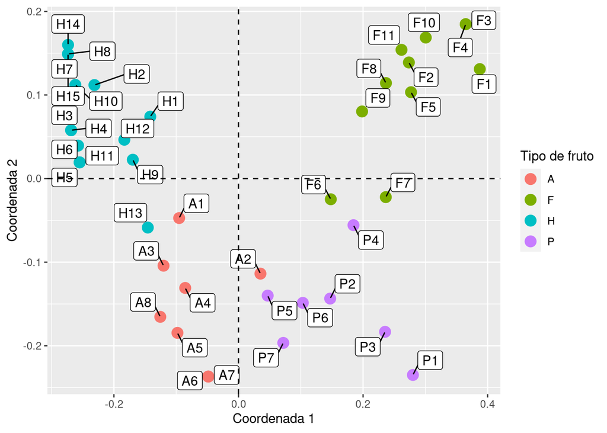

Figura 1: Caracterizacion molecular de las variedades de pepino.

```r
ggplot(datos_CP) +
  geom_point(aes(c1, c2, color = variedad), size = 4) +
  geom_label_repel(aes(c1, c2, label = etiqueta), max.overlaps = 30) +
  geom_vline(xintercept = 0, linetype = "dashed") +
  geom_hline(yintercept = 0, linetype = "dashed") +
  labs(
    x = "Coordenada 1",
    y = "Coordenada 2",
    color = "Tipo de fruto"
  )
```

**D.** Encuentre el dendograma ultramétrico con ligamiento UPGMA

```r
cluster_molecular <- hclust(matriz_distancia, method = "average")
dendro_data <- dendro_data_k(cluster_molecular, k=4)
```

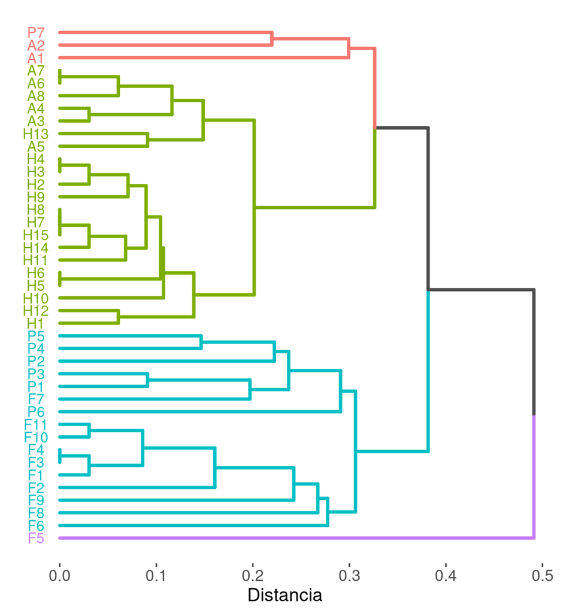

Figura 2: Dendograma Ultrametrico con ligamiento UPGMA.

```r
ggplot(dendro_data$segments) +
  geom_segment(
    aes(x = x, y = y, xend = xend, yend = yend, color = as.factor(clust)),
    size = 1.2,
    lineend = "round"
  ) +
  geom_text(
    aes(x = x, y = y - 0.025, label = label, color = as.factor(clust)),
    data = dendro_data$labels
  ) +
  coord_flip() +
  labs(
    y = "Distancia"
  ) +
  scale_colour_manual(
    values = c("grey30", scales::hue_pal()(4))
  ) +
  theme(
    panel.grid.major = element_blank(),
    panel.grid.minor = element_blank(),
    panel.background = element_blank(),
    axis.title.x = element_text(size = 14),
    axis.title.y = element_blank(),
    axis.text.x = element_text(size = 12),
    axis.text.y = element_blank(),
    axis.line = element_blank(),
    axis.ticks.y = element_blank(),
    plot.title = element_text(hjust = 0.5),
    legend.position = "none"
  )
```

**E.** Mida a través de su matriz cofenética la concordancia con la matriz de distancias que le dio origen

Primero vamos a calcular la concordancia y luego obtenemos un grafico de dispersion donde se muestra la distancia original y la distancia cofenética.

```r
distancia_cofenetica_upgma <- cophenetic(cluster_molecular)
concordancia <- cor(matriz_distancia, distancia_cofenetica_upgma)
```

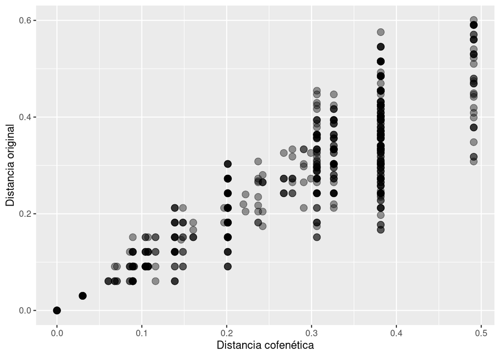

Figura 3: Grafico de dispersion entre distancia original y distancia cofenética.

```r
concordancia_df <- data.frame(
    x = as.vector(distancia_cofenetica_upgma),
    y = as.vector(matriz_distancia)
)
ggplot(concordancia_df) +
    geom_point(aes(x, y), size = 3, alpha = 0.4) +
    labs(
        x = "Distancia cofenética",
        y = "Distancia original"
    )
```

La concordancia entre la matriz de distancias cofenética y la matriz de distancia original es igual a 0.872.

**F.** Halle el dendograma aditivo Neighbor Joining

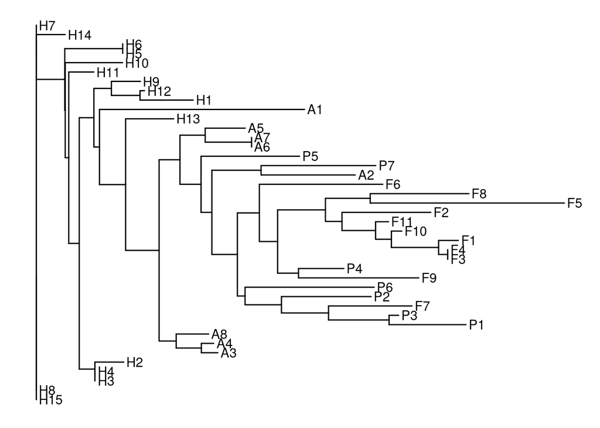

```r
rapds_nj <- nj(matriz_distancia)
ggtree::ggtree(rapds_nj, ladderize = FALSE) + ggtree::geom_tiplab()
```

**G.** Mida su concordancia con matriz de distancia original

Me da cualquier cosa!!

```r
distancia_cofenetica_nj <- as.dist(cophenetic(rapds_nj), diag = TRUE, upper = FALSE)
```

```r
cor(distancia_cofenetica_nj, matriz_distancia)
```

```
## [1] 0.0004200486
```

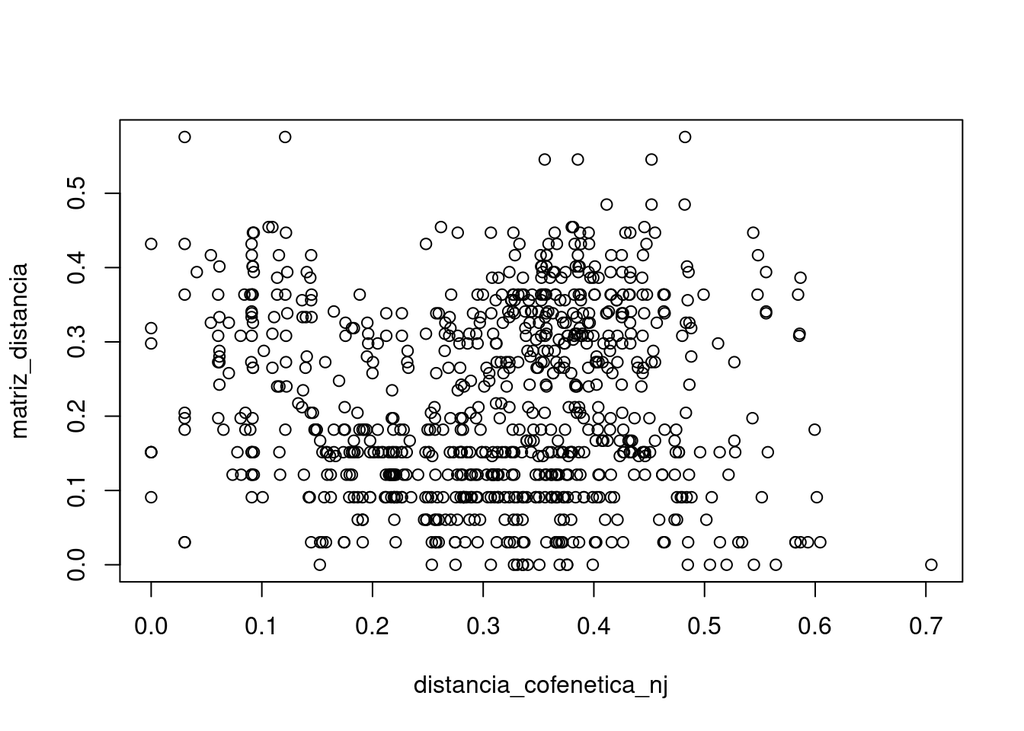

```r
plot(distancia_cofenetica_nj, matriz_distancia)
```

**H.** Relacione ambos dendogramas y saque conclusiones

Pero este me da bien!!

```r
cor(distancia_cofenetica_nj, distancia_cofenetica_upgma)
```

```
## [1] 0.8720294
```

Replico lo que hace el profe…

```r
RAPDS <- read.table(here::here("data", "raw", "RAPDS.csv"), row.names = 1, sep = ";", dec = ",", header = TRUE)
RAPDS.MANHA <- dist(RAPDS, method = "manhattan", diag = TRUE) / 33
library(ape)
RAPDS.NJ <- nj(RAPDS.MANHA)
RAPDS.NJ.COF <- cophenetic(RAPDS.NJ)
RAPDS.NJ.COF2 <- as.dist(RAPDS.NJ.COF, diag=TRUE, upper=FALSE)
cor(RAPDS.NJ.COF2, RAPDS.MANHA)
```

```
## [1] 0.0004200486
```

Y me da nada que ver (a el le da 0.9256675, hora 4:15:43 de clase del 27-04)